# Exploring Characteristics of Desmosome-Associated mRNA

Sophia Link

November 05, 2023

## The Data

The data set for this analysis was produced by Kwabena A. Badu-Nkansah and Terry Lechler as described in [*Proteomic analysis of desmosomes reveals novel components required for epidermal integrity*](https://www.molbiolcell.org/doi/10.1091/mbc.E19-09-0542?url_ver=Z39.88-2003&rfr_id=ori:rid:crossref.org&rfr_dat=cr_pub%20%200pubmed).  
In short, a Desmoplakin-BirA fusion was used to biotinylate molecules that came into proximity of the desmosome. A streptavidin pull down, followed by RNAseq generated a list of RNA that came into close proximity with the desmosome.

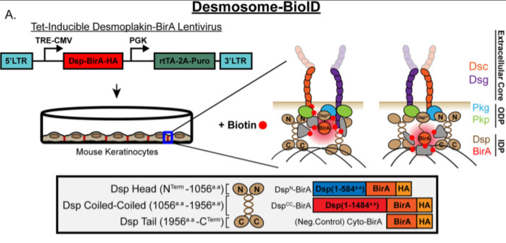

Desmoplakin Biotinylation Construct (adapted from Badu-Nkansah & Lechler, 2020)

## Defining Enrichment

RNAs enriched at the desmosome will be defined as those with a p-value less than 0.01 and greater than a 2 fold change in detection in the desmosome pull-down compared to the cytoplasmic one.  
RNAs depleted at the desmosome similarly, are defined as those with a p-value less than 0.01 and a less than 0.5 fold change.

This definition is derived from an earlier paper that characterized RNAs enriched in stress granules [(Khong et al., 2017)](https://www.ncbi.nlm.nih.gov/pmc/articles/PMC5728175/).

```r
dp <- mutate(dp, Status = if_else(((dp$p_Value<0.01) & (dp$Fold_Change>2)), "Enriched", if_else(((dp$p_Value<0.01) & (dp$Fold_Change<0.5)), "Depleted", "Neither")))

glimpse(dp)
```

```
## Rows: 15,822
## Columns: 7
## $ Ensembl_ID       <chr> "ENSMUSG00000000001", "ENSMUSG00000000028", "ENSMUSG0…
## $ Gene_Name        <chr> "Gnai3", "Cdc45", "H19", "Apoh", "Narf", "Cav2", "Klf…
## $ Fold_Change      <dbl> 0.0546930, 2.2700121, 102.8430150, 2.8380500, 0.23658…
## $ log2_Fold_Change <dbl> -4.19250, 1.18270, 6.68430, 1.50490, -2.07960, -1.999…
## $ p_Value          <dbl> 1.4004e-06, 4.7623e-02, 4.4594e-16, 3.8203e-01, 4.811…
## $ Gene_Length      <dbl> 3262, 2143, 2286, 1190, 4395, 2733, 4217, 3544, 690, …
## $ Status           <chr> "Depleted", "Neither", "Enriched", "Neither", "Neithe…
```

## Gathering More Information

The Ensembl genome database has a helpful tool, [Ensembl BioMart](https://useast.ensembl.org/biomart/martview/e8d6b66a62d243081b95f8dfa800c0ab), for pulling sequence information about a large number of genes.  
Let’s look at the length of different parts of the transcripts.

```r
glimpse(length_data)
```

```
## Rows: 190,483
## Columns: 5
## $ Ensembl_ID        <chr> "ENSMUSG00000000001", "ENSMUSG00000000001", "ENSMUSG…
## $ Transcript_Length <dbl> 3262, 3262, 3262, 3262, 2143, 2143, 2143, 2143, 2143…
## $ CDS_Length        <dbl> 1065, 1065, 1065, 1065, 1701, 1701, 1701, 1701, 1701…
## $ `Length_5'UTR`    <dbl> NA, 140, NA, NA, NA, 143, 168, NA, NA, NA, NA, NA, 6…
## $ `Length_3'UTR`    <dbl> NA, NA, 2036, 18, NA, NA, NA, 126, 1, 120, 1, NA, NA…
```

## Exploratory Data Analysis

Is there a relationship between the length of the gene or a region of the transcript and it’s enrichment at the desmosome?

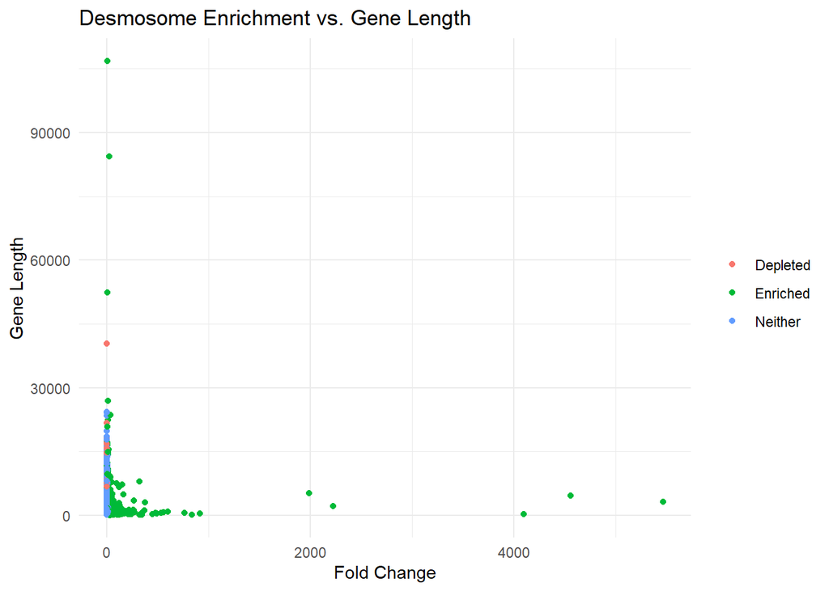

```r
ggplot(dp_lengths) +
  theme_minimal() +
  labs(x = "Fold Change", y = "Gene Length", title = "Desmosome Enrichment vs. Gene Length", color = NULL) +
  geom_point(aes(x = Fold_Change, y = Gene_Length, color = Status))
```

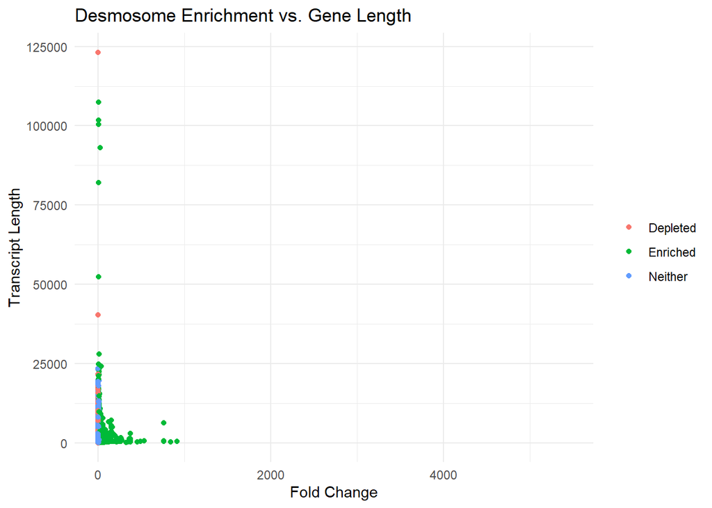

```r
ggplot(dp_lengths) +
  theme_minimal() +
  labs(x = "Fold Change", y = "Transcript Length", title = "Desmosome Enrichment vs. Gene Length", color = NULL) +
  geom_point(aes(x = Fold_Change, y = Transcript_Length, color = Status))
```

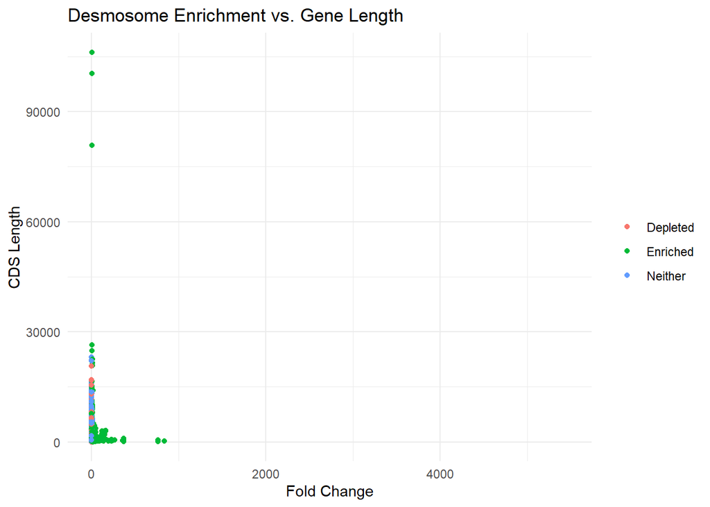

```r
ggplot(dp_lengths) +
  theme_minimal() +
  labs(x = "Fold Change", y = "CDS Length", title = "Desmosome Enrichment vs. Gene Length", color = NULL) +
  geom_point(aes(x = Fold_Change, y = CDS_Length, color = Status))
```

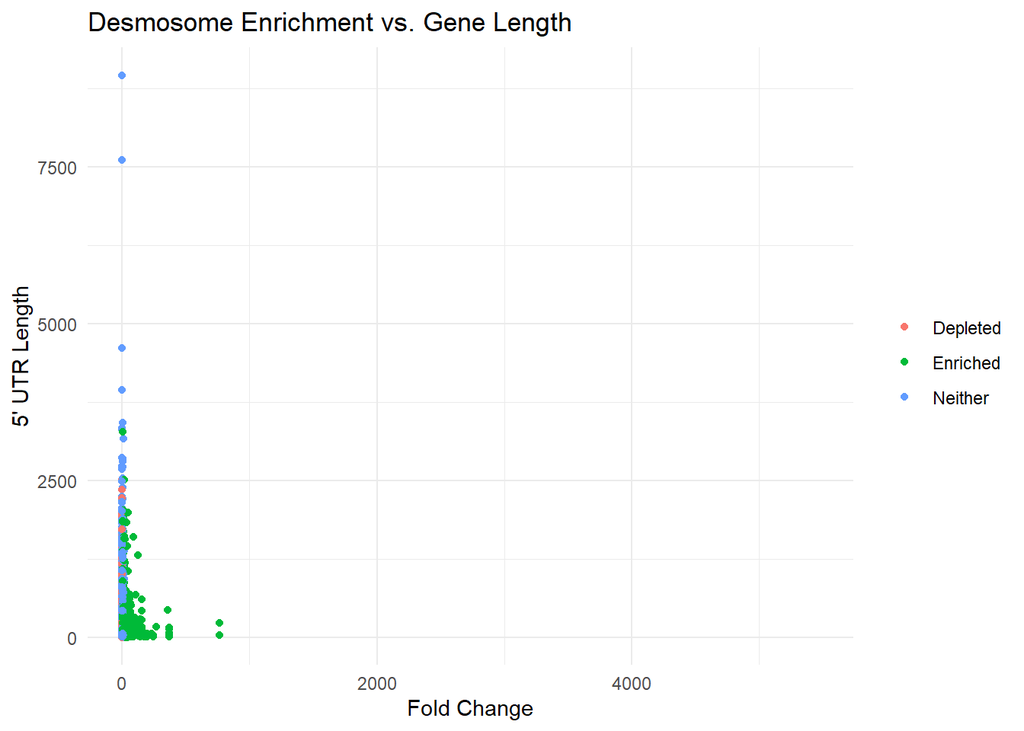

```r
ggplot(dp_lengths) +
  theme_minimal() +
  labs(x = "Fold Change", y = "5' UTR Length", title = "Desmosome Enrichment vs. Gene Length", color = NULL) +
  geom_point(aes(x = Fold_Change, y = dp_lengths$"Length_5'UTR", color = Status))
```

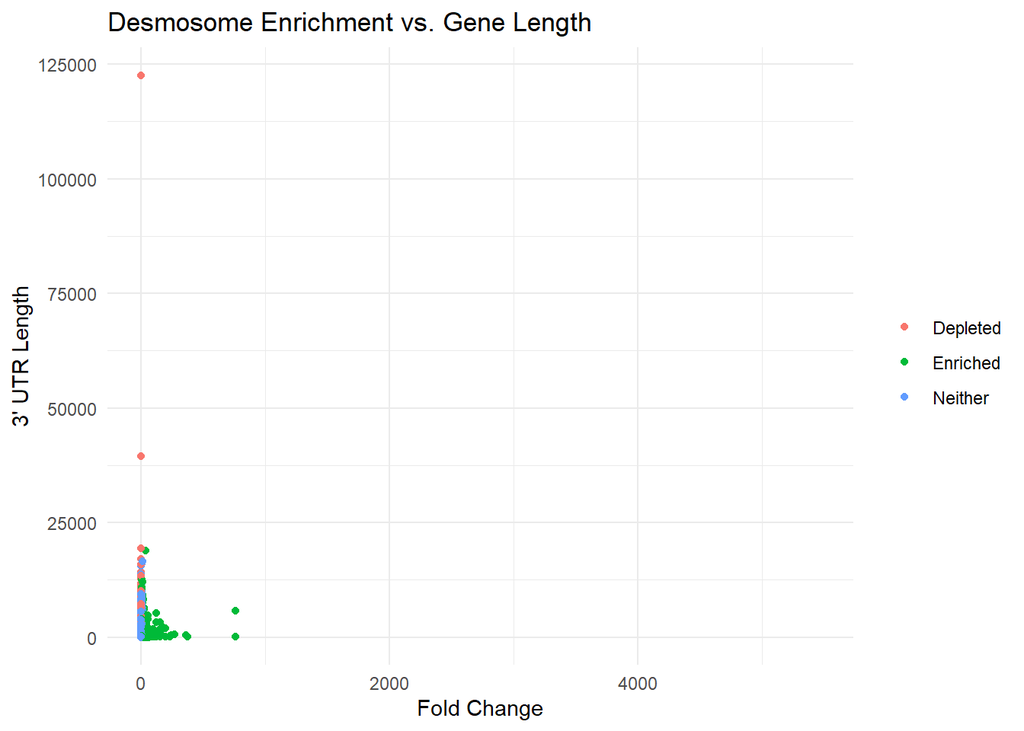

```r
ggplot(dp_lengths) +
  theme_minimal() +
  labs(x = "Fold Change", y = "3' UTR Length", title = "Desmosome Enrichment vs. Gene Length", color = NULL) +
  geom_point(aes(x = Fold_Change, y = dp_lengths$"Length_3'UTR", color = Status))
```

There is a wide range of values for both the fold change and length data points making it hard to detect any relationships.

Let’s take the log<sub>2</sub>() of these values to give us a clearer picture.

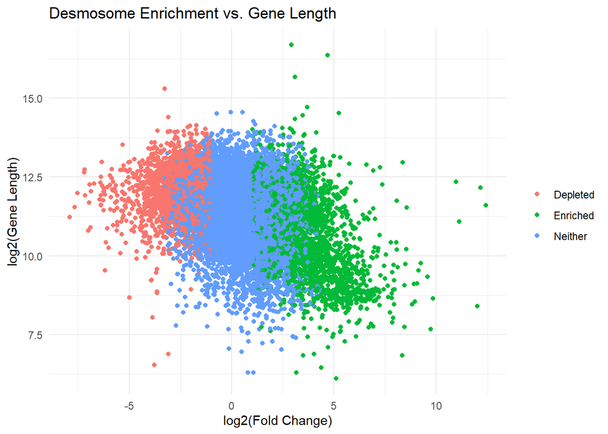

```r
ggplot(dp_lengths) +
  theme_minimal() +
  labs(x = "log2(Fold Change)", y = "log2(Gene Length)", title = "Desmosome Enrichment vs. Gene Length", color = NULL) +
  geom_point(aes(x = log2_Fold_Change, y = log(Gene_Length,2), color = Status))
```

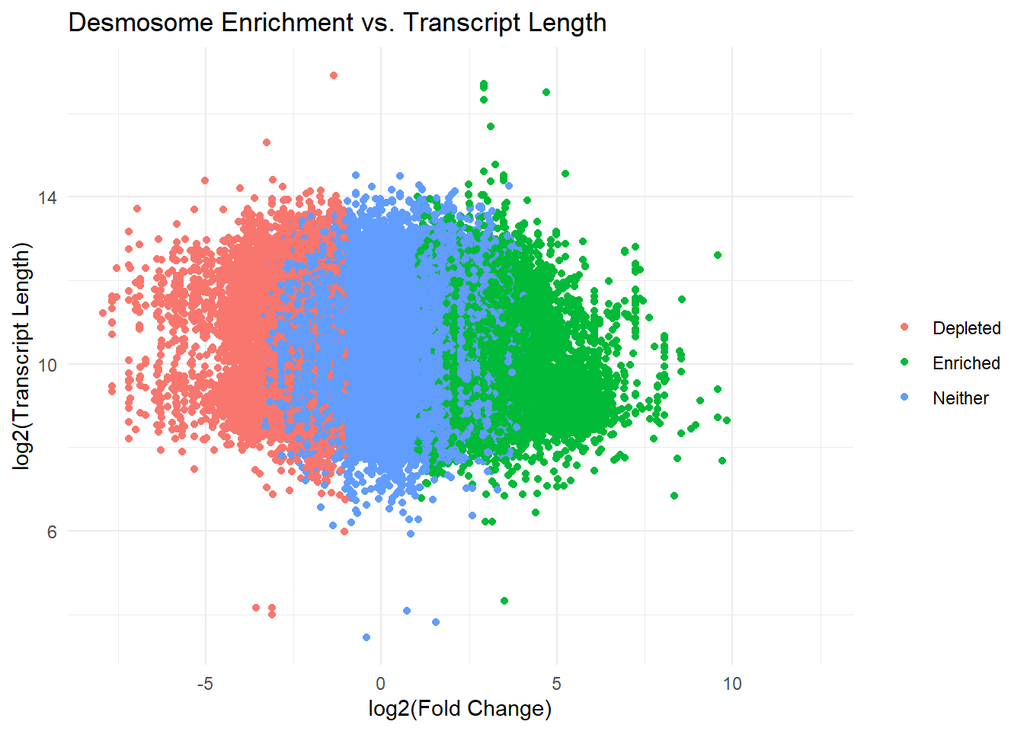

```r
ggplot(dp_lengths) +
  theme_minimal() +
  labs(x = "log2(Fold Change)", y = "log2(Transcript Length)", title = "Desmosome Enrichment vs. Transcript Length", color = NULL) +
  geom_point(aes(x = log2_Fold_Change, y = log(Transcript_Length,2), color = Status))
```

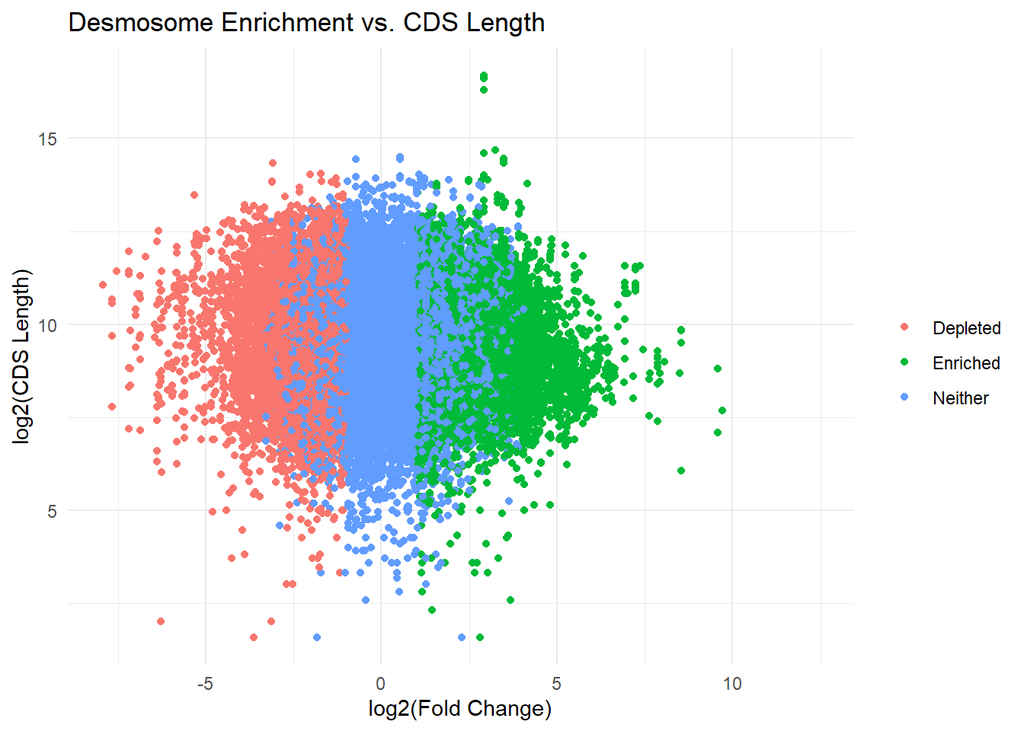

```r
ggplot(dp_lengths) +
  theme_minimal() +
  labs(x = "log2(Fold Change)", y = "log2(CDS Length)", title = "Desmosome Enrichment vs. CDS Length", color = NULL) +
  geom_point(aes(x = log2_Fold_Change, y = log(CDS_Length,2), color = Status))
```

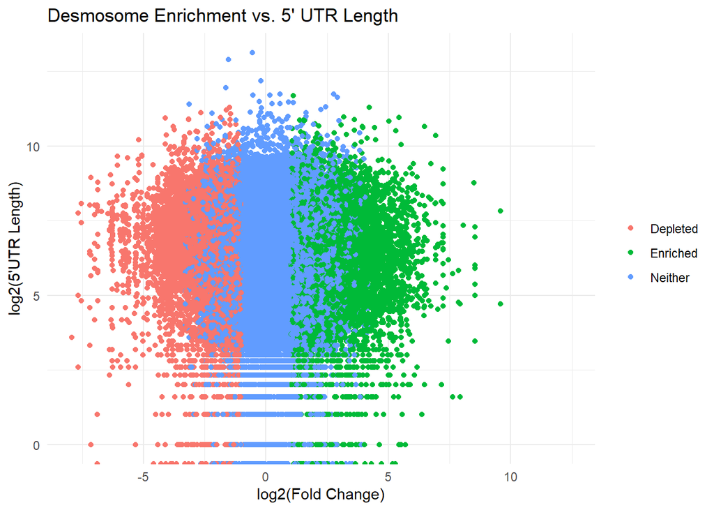

```r
ggplot(dp_lengths) +
  theme_minimal() +
  labs(x = "log2(Fold Change)", y = "log2(5'UTR Length)", title = "Desmosome Enrichment vs. 5' UTR Length", color = NULL) +
  geom_point(aes(x = log2_Fold_Change, y = log(dp_lengths$"Length_5'UTR",2), color = Status))
```

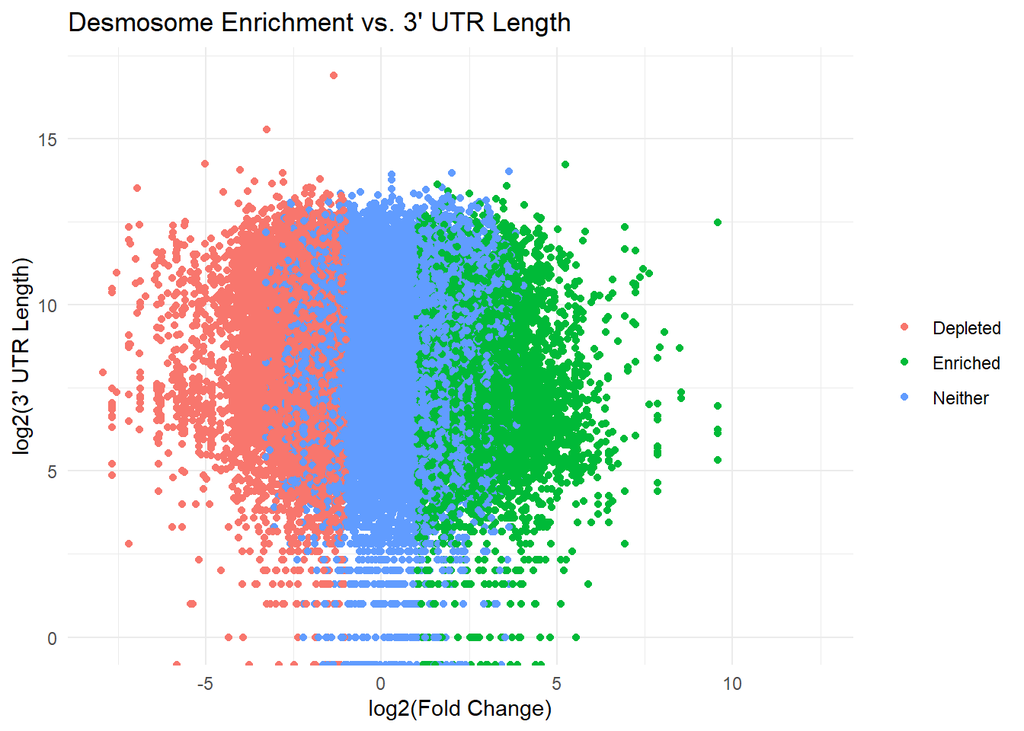

```r
ggplot(dp_lengths) +
  theme_minimal() +
  labs(x = "log2(Fold Change)", y = "log2(3' UTR Length)", title = "Desmosome Enrichment vs. 3' UTR Length", color = NULL) +
  geom_point(aes(x = log2_Fold_Change, y = log(dp_lengths$"Length_3'UTR",2), color = Status))
```

## Final Graph

While these graphs are much clearer, there does not seem to be any relationship *except* perhaps a slight trend towards shorter gene being enriched.

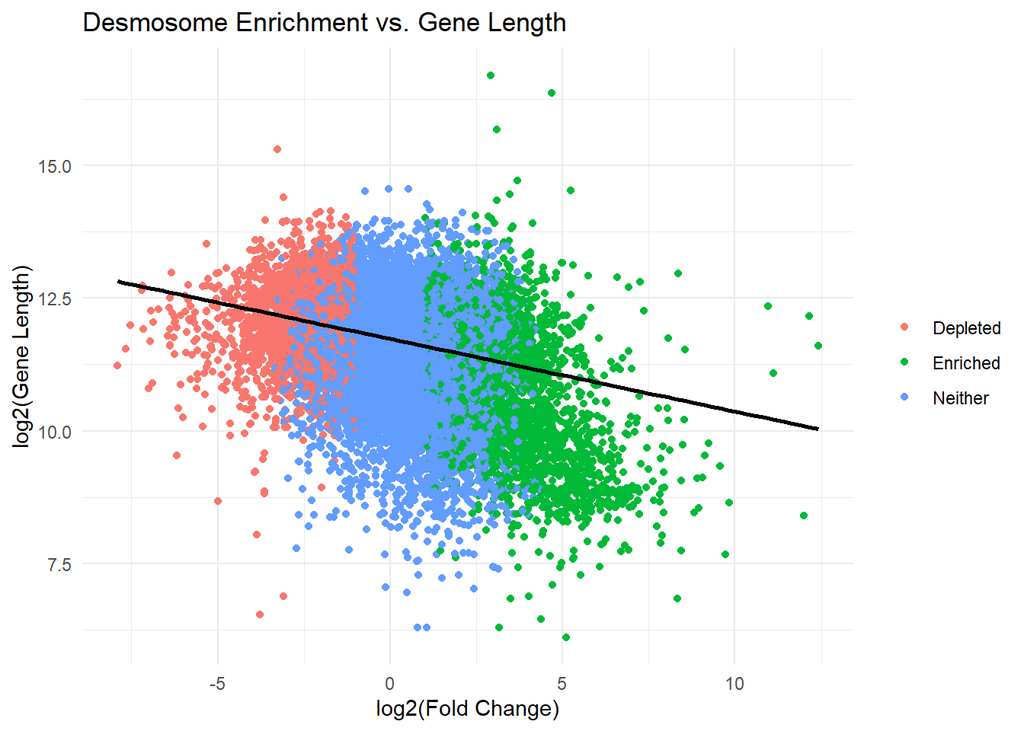

```r
ggplot(dp_lengths) +
  theme_minimal() +
  labs(x = "log2(Fold Change)", y = "log2(Gene Length)", title = "Desmosome Enrichment vs. Gene Length", color = NULL) +
  geom_point(aes(x = log2_Fold_Change, y = log(Gene_Length,2), color = Status)) +
  geom_smooth(aes(x = log2_Fold_Change, y = log(Gene_Length,2)), method = "lm", color = "black")
```

## Conclusions

The lack of a strong correlation between enrichment in the desmosome-proximal RNA segment and gene, transcript, CDS or UTR length, suggests that these characteristics are not enough to explain the localization of these genes to the demsosome.

Instead, there is likely some sequence in the desmosome-localized mRNAs that causes them to be enriched in this region.

## Prioritized Follow-Up Studies

Use the Ensemble data base to get the sequence information for the enriched mRNA and look for similar regions that may constitute desmosome-localization signals.

## Acknowledgement

Big thanks to Kwabena A. Badu-Nkansah and Terry Lechler who collected this data and allowed me to work with it for this project.